# Manejando series de tiempo de financieras con R

[figure not shown]

# Principales Características

El precio de algunas acciones no son estacionarias.

[figure not shown]

La serie de retornos tiene una distribución leptocúrtica.

[figure not shown]

En los mercados financieros el proceso de la serie de retornos es un ruido blanco, pero las observaciones no son independientes.

[figure not shown]

volatility clustering

[figure not shown]

## ¿Por qué usar la serie de retornos y no de precios?

1. Resumen de la oportunidad de inversión
2. Series de retornos más fáciles de manejar por sus propiedades estadísticas.

## Como calcular los retornos

### Retornos de forma discreta

[figure not shown]

### Retornos de forma contínua

[figure not shown]

# Propiedades de las distribuciones de los retornos

## Distribución conjunta

[figure not shown]

## Distribuciones Estables

1. Capturan el exceso de curtosis
2. Tienen varianza infinita

## Mezcla a escala de distribuciones Normales

[figure not shown]

### Propiedades empíricas de las series de retornos

1. Los retornos diarios de los índices de mercado y las acciones tienden a tener un exceso de curtosis.
2. La media de las series de retorno en frecuencia diaria es cercana a cero, los retornos mensuales son mayores.
3. Los retornos mensuales tienen mayor desviacion estandar que los diarios

# Modelación de la heteroscedasticidad

## Modelos ARCH

## Modelos GARCH

# Las librerías a usar

1. Fbasics
2. Time Date
3. Parallel
4. Rugarch
5. tseries
6. zoo
7. lmtest
8. forecast

```r
library(fBasics)
library(timeDate)
library(timeSeries)
library(parallel)
library(rugarch)
library(tseries)
library(fBasics)
library(zoo)
library(lmtest)
library(forecast)
```

```r
# Estableciendo el directorio de trabajo
setwd("C:\\Users\\IN_CAP02\\Desktop\\Proyecto")

# Cargando los datos en un tabla
apple = read.table("AAPL.csv", header=T, sep=',')

# Generando serie de tiempo financiera con los precios de cierre
applets <- zoo(apple$Adj.Close, as.Date(as.character(apple$Date), format = c("%Y-%m-%d")))
```

```r
# Obteniendo las series de retornos del precio de la acción

# Retorno logarítmicos
apple_retl <- log(applets/lag(applets,-1))

# Retorno simples
apple_rets <- ((applets/lag(applets,-1))-1)
```

```r
#Quitar las fechas y crear objetos númericos con una función de zoo
apple_retl_num <- coredata(apple_retl)
```

# Grafica precios de la acción

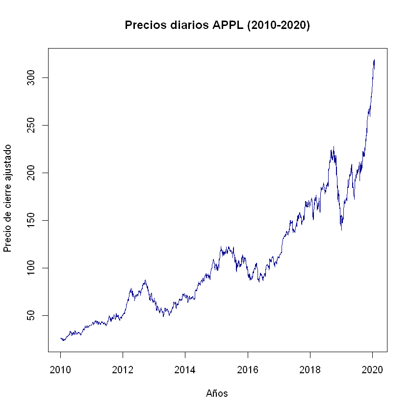

```r
plot(applets, type='l', xlab = "Años", ylab = " Precio de cierre ajustado", main="Precios diarios APPL (2010-2020)", col = 'darkblue')
```

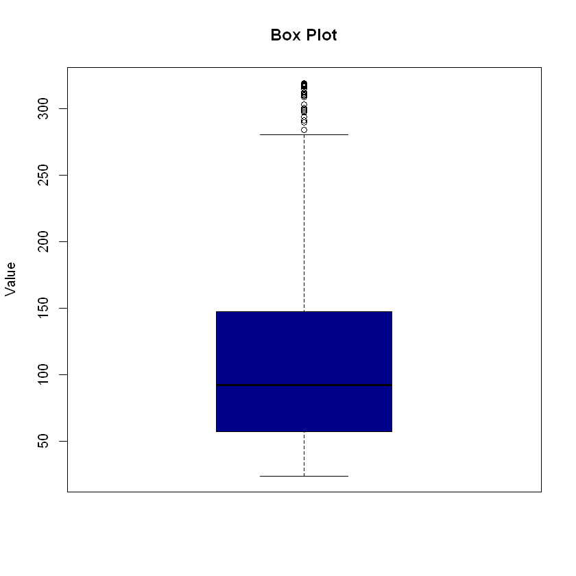

```r
boxPlot(applets, col="darkblue", title = TRUE)
```

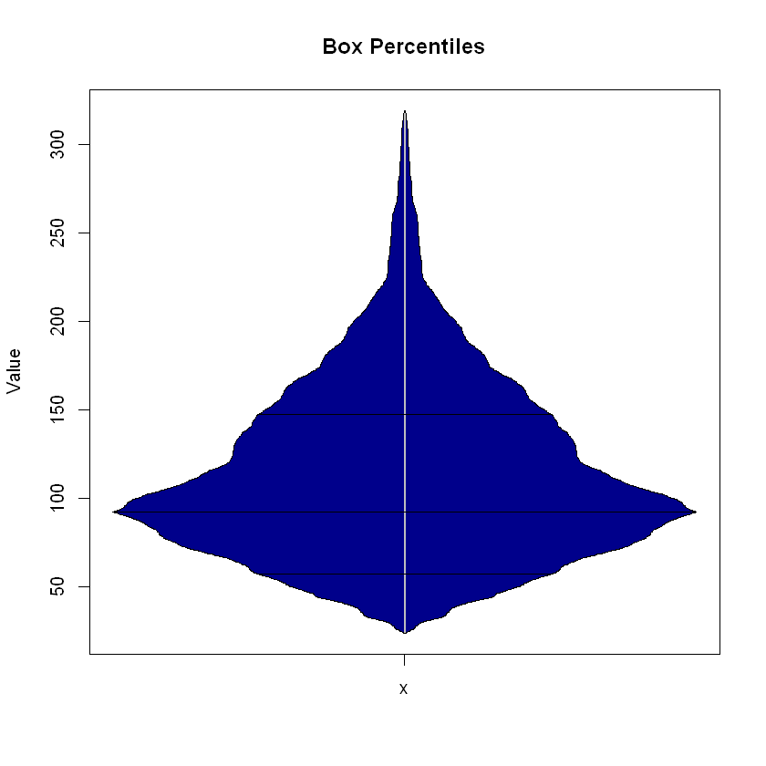

```r
boxPercentilePlot(applets, col="darkblue", title = TRUE)
```

# Estadísticas Básicas de la serie de precios

```r
basicStats(applets)
```

A data.frame: 16 × 1

|  | x <dbl> |
| --- | --- |
| nobs | 2.533000e+03 |
| NAs | 0.000000e+00 |
| Minimum | 2.387184e+01 |
| Maximum | 3.192300e+02 |
| 1. Quartile | 5.732701e+01 |
| 3. Quartile | 1.477796e+02 |
| Mean | 1.054454e+02 |
| Median | 9.237116e+01 |
| Sum | 2.670933e+05 |
| SE Mean | 1.189097e+00 |
| LCL Mean | 1.031137e+02 |
| UCL Mean | 1.077771e+02 |
| Variance | 3.581541e+03 |
| Stdev | 5.984598e+01 |
| Skewness | 9.018750e-01 |
| Kurtosis | 3.214560e-01 |

# Correlograma

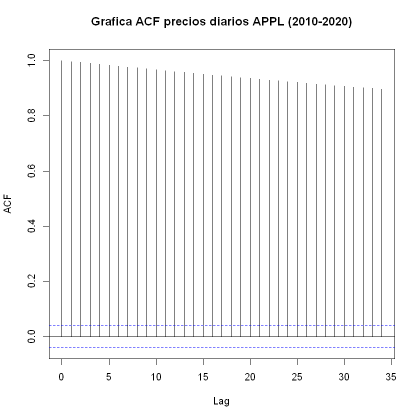

```r
acf(coredata(applets), main="Grafica ACF precios diarios APPL (2010-2020)")
```

# Correlación Parcial

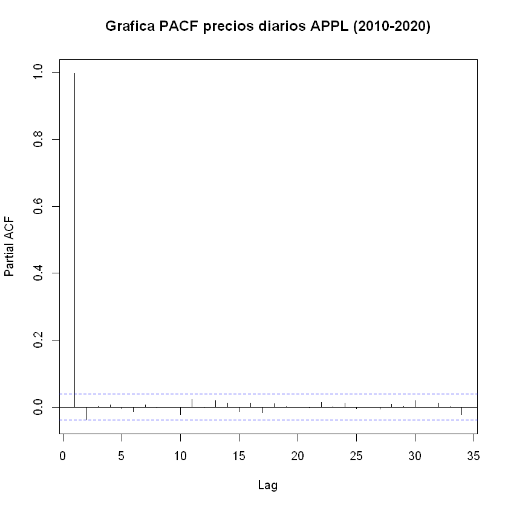

```r
pacf(coredata(applets), main="Grafica PACF precios diarios APPL (2010-2020)")
```

# Estadísticas Básicas de la serie de Retornos

```r
basicStats(apple_retl)
```

A data.frame: 16 × 1

|  | x <dbl> |
| --- | --- |
| nobs | 2532.000000 |
| NAs | 0.000000 |
| Minimum | -0.131885 |
| Maximum | 0.085022 |
| 1. Quartile | -0.006768 |
| 3. Quartile | 0.009818 |
| Mean | 0.000968 |
| Median | 0.000951 |
| Sum | 2.452213 |
| SE Mean | 0.000322 |
| LCL Mean | 0.000336 |
| UCL Mean | 0.001601 |
| Variance | 0.000263 |
| Stdev | 0.016225 |
| Skewness | -0.342724 |
| Kurtosis | 4.810776 |

# Estadísticas Básicas de la serie de retornos log.

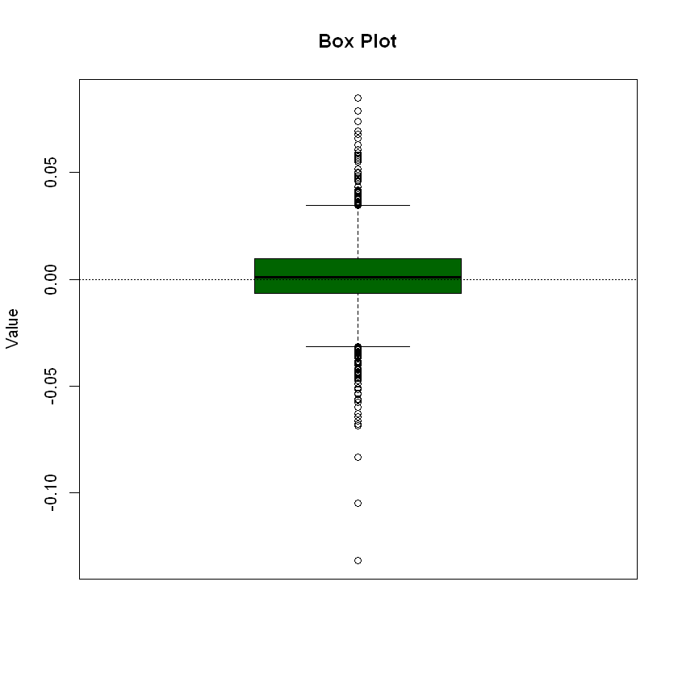

```r
boxPlot(apple_retl, col="darkgreen", title = TRUE)
```

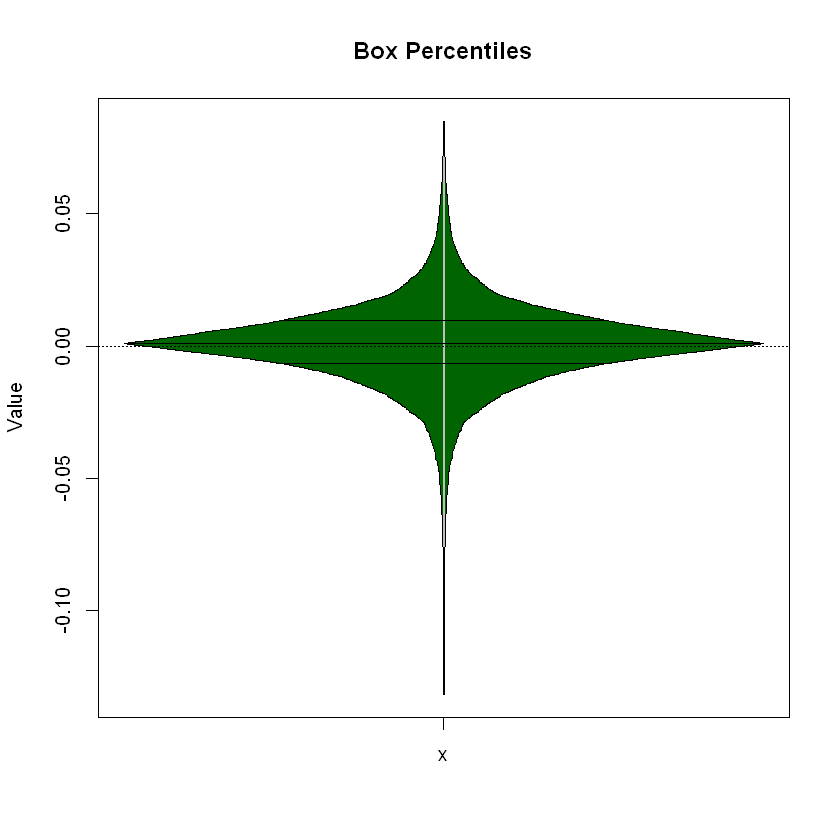

```r
boxPercentilePlot(apple_retl, col="darkgreen", title = TRUE)
```

# Histograma de los retornos diarios de Apple

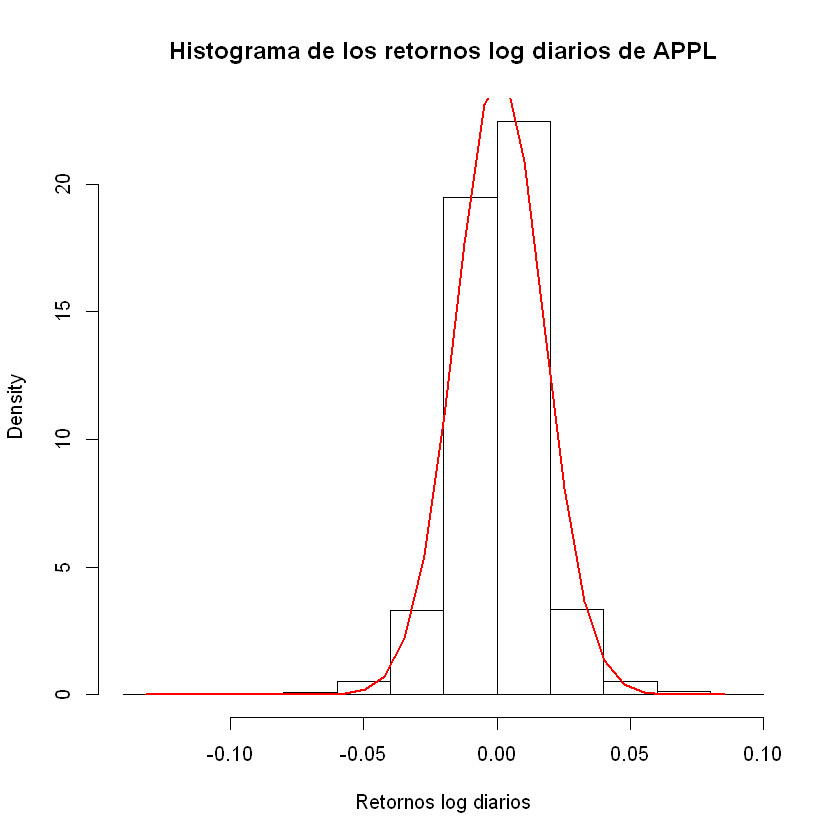

```r
hist(apple_retl, xlab="Retornos log diarios", prob=TRUE, main="Histograma de los retornos log diarios de APPL");
xfit<-seq(min(apple_retl),max(apple_retl),length=30);
yfit<-dnorm(xfit,mean=mean(apple_retl),sd=sd(apple_retl));
lines(xfit, yfit, col="red", lwd=2)
```

# Pruebas de Normalidad

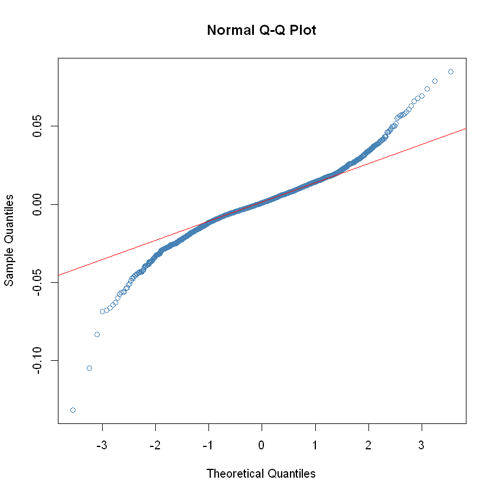

```r
qqnorm(apple_retl, col ="steelblue")
qqline(apple_retl, col = "red")
```

```r
jarque.bera.test(apple_retl)
a= adTest(apple_retl, title = NULL, description = NULL)
a
```

```
	Jarque Bera Test

data:  apple_retl
X-squared = 2497.5, df = 2, p-value < 2.2e-16
```

```
Title:
 Anderson - Darling Normality Test

Test Results:
  STATISTIC:
    A: 21.3725
  P VALUE:
    < 2.2e-16

Description:
 Thu Jan 30 23:39:11 2020 by user: IN_CAP02
```

# Pruebas de Estacionariedad

```r
adf.test(apple_retl, k=13)
```

```
	Augmented Dickey-Fuller Test

data:  apple_retl
Dickey-Fuller = -12.891, Lag order = 13, p-value = 0.01
alternative hypothesis: stationary
```